# Causal Graphs in R

## ggdag

### Reference links:

1. https://ggdag.netlify.com/articles/intro-to-ggdag.html
2. https://ggdag.netlify.com/articles/intro-to-dags.html
3. https://ggdag.netlify.com/articles/bias-structures.html

### Basics:

```r
library(ggdag)
```

#### Directed edge

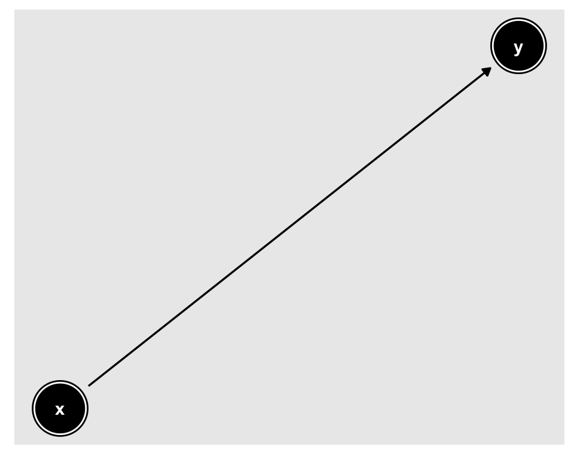

```r
dagify(y ~ x) %>%
  ggdag()
```

#### Bi-directed edge

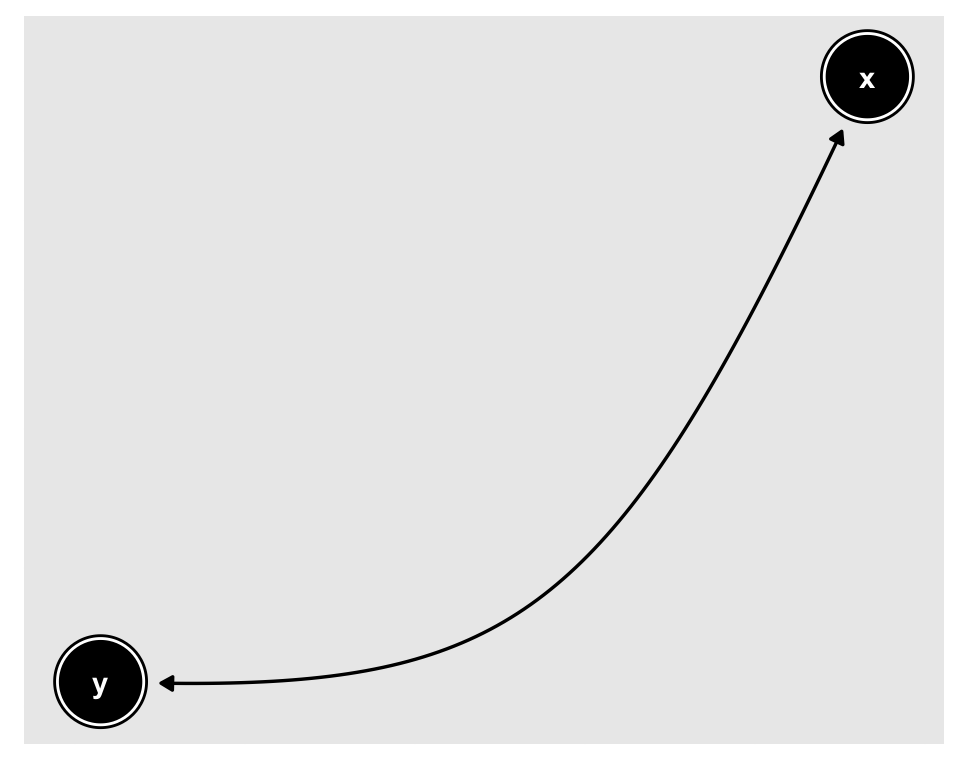

```r
dagify(y ~~ x) %>%
  ggdag()
```

#### Latent variable

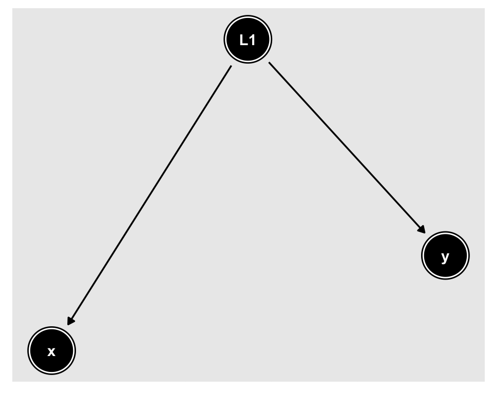

```r
dagify(y ~~ x) %>%
  ggdag_canonical()
```

#### x is a confounder

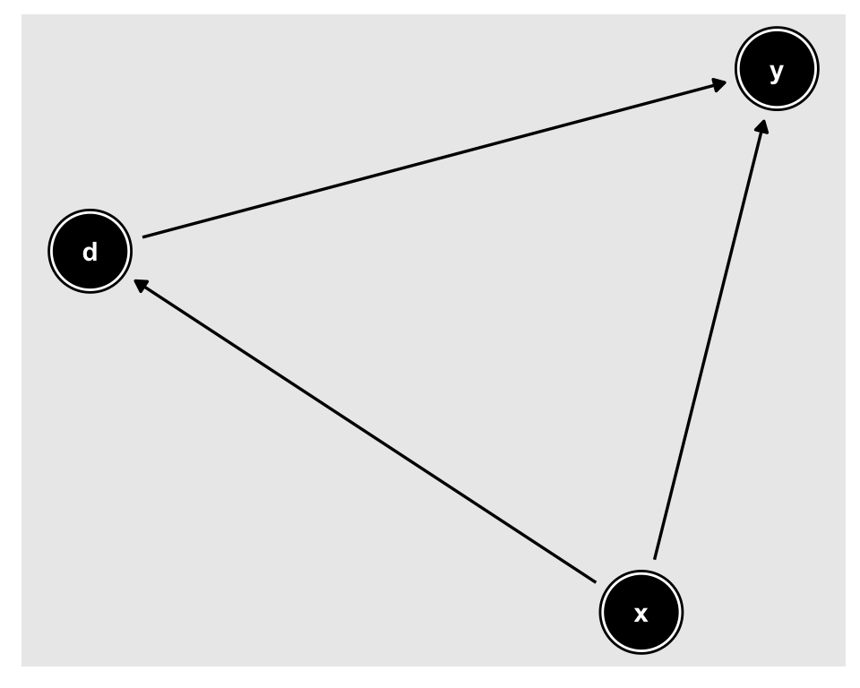

```r
dagify(y ~ x,
       d ~ x,
       y ~ d) %>%
  ggdag()
```

#### x is a mediator

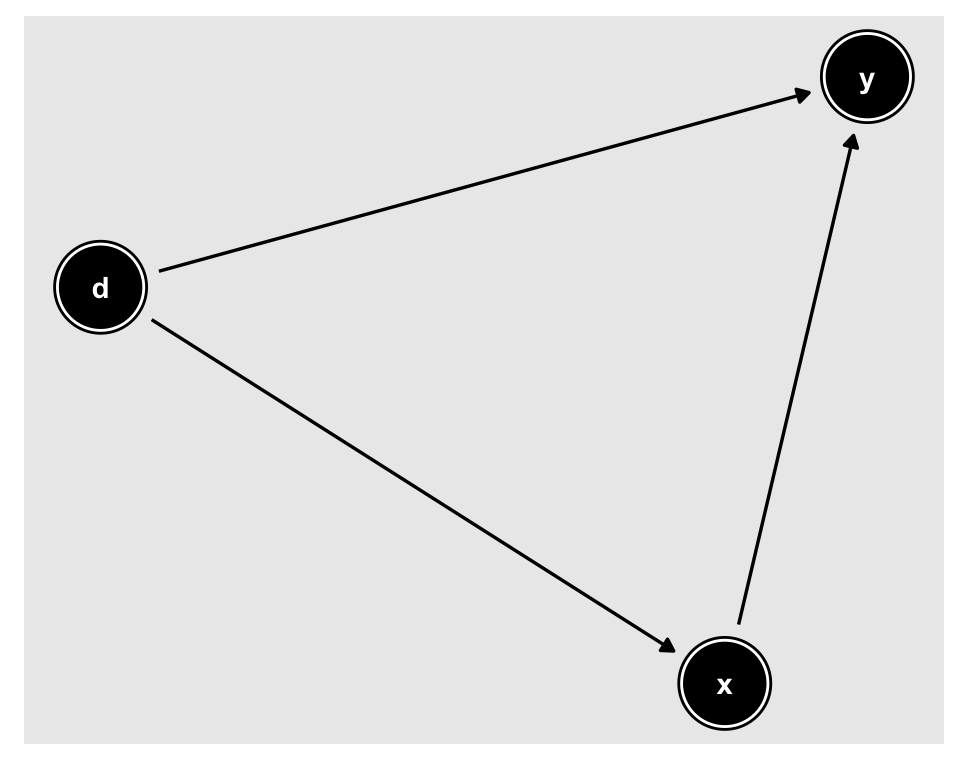

```r
dagify(y ~ x,
       x ~ d,
       y ~ d) %>%
  ggdag()
```

#### x is a collider

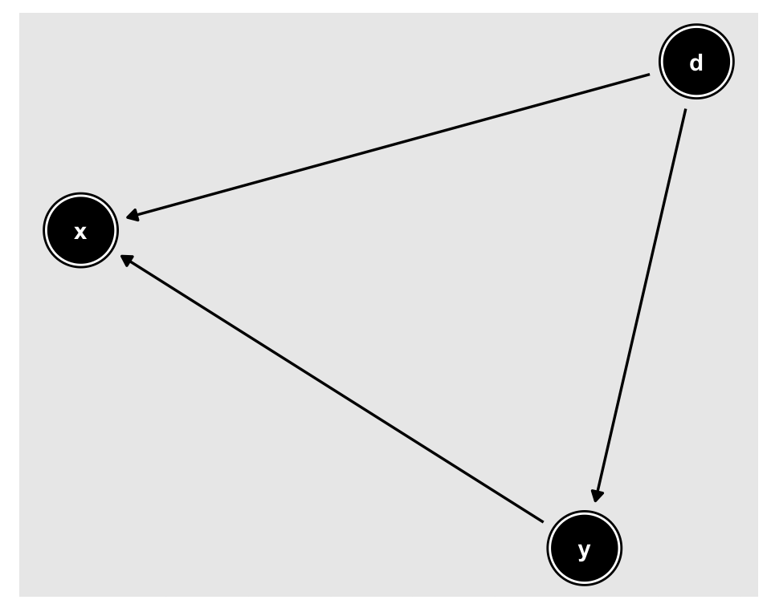

```r
dagify(x ~ y,
       x ~ d,
       y ~ d) %>%
  ggdag()
```

### More complicated example:

Let’s say we’re looking at the relationship between smoking and cardiac arrest. We might assume that smoking causes changes in cholesterol, which causes cardiac arrest:

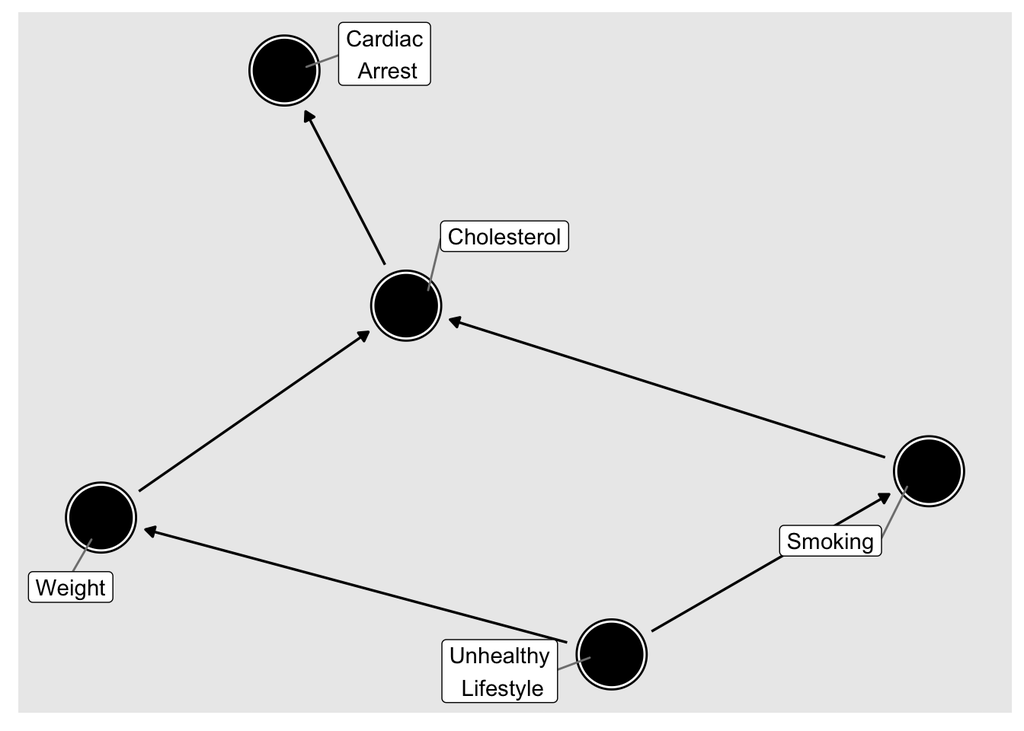

```r
smoking_ca_dag <- dagify(cardiacarrest ~ cholesterol,
                         cholesterol ~ smoking + weight,
                         smoking ~ unhealthy,
                         weight ~ unhealthy,
                         labels = c("cardiacarrest" = "Cardiac\n Arrest",
                                    "smoking" = "Smoking",
                                    "cholesterol" = "Cholesterol",
                                    "unhealthy" = "Unhealthy\n Lifestyle",
                                    "weight" = "Weight"),
                         latent = "unhealthy",
                         exposure = "smoking",
                         outcome = "cardiacarrest")

ggdag(smoking_ca_dag, # the dag object we created
      text = FALSE, # this means the original names won't be shown
      use_labels = "label") # instead use the new names
```

In this example, we:

1. Used more meaningful variable names
2. Created a variable that was the result of two variables vs. just one (cholesterol)
3. Used the “labels” argument to rename our variables (this is useful if your desired final variable name is more than one word)
4. Specified which variables are latent, the exposure, and outcome

We can also highlight the pathways between variables:

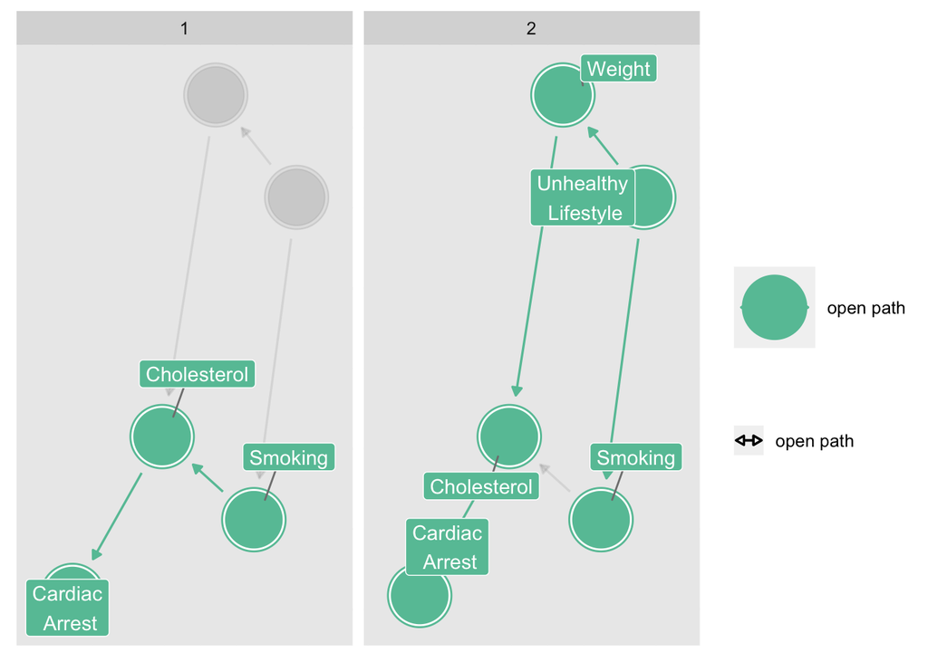

```r
ggdag_paths(smoking_ca_dag,
            text = FALSE,
            use_labels = "label")
```

Or to show what happens when we condition on a variable. In this example, “fever” is a collider.

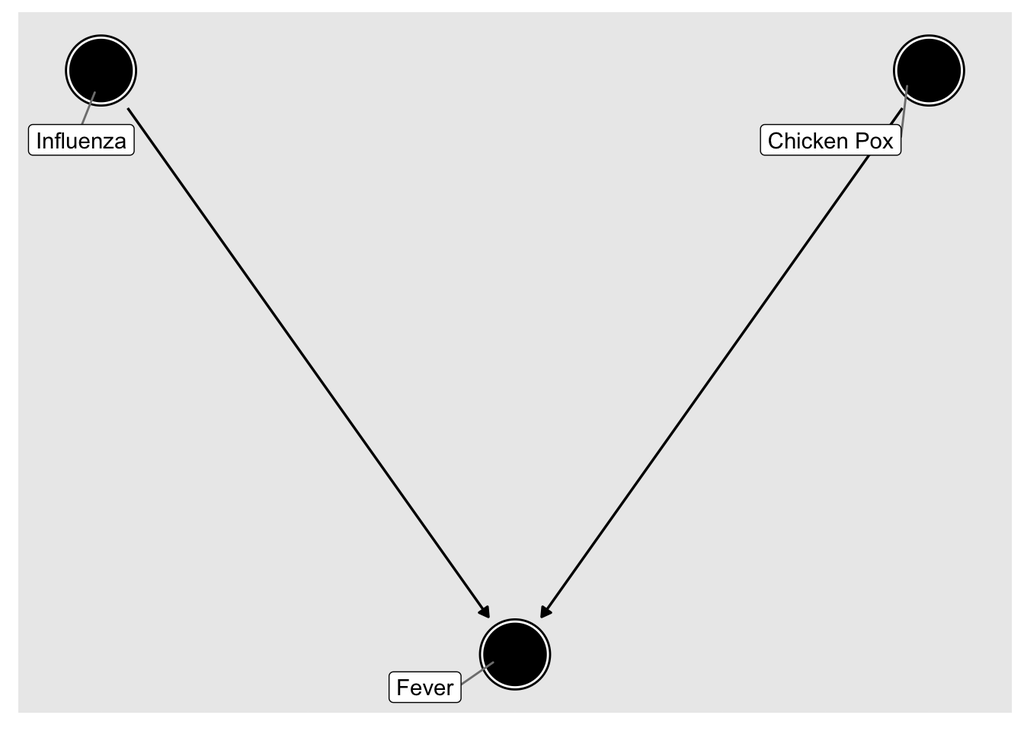

```r
fever_dag <- collider_triangle(x = "Influenza",
                               y = "Chicken Pox",
                               m = "Fever")

ggdag(fever_dag,
      text = FALSE,
      use_labels = "label")
```

We can see that flu and chickenpox are d-separated

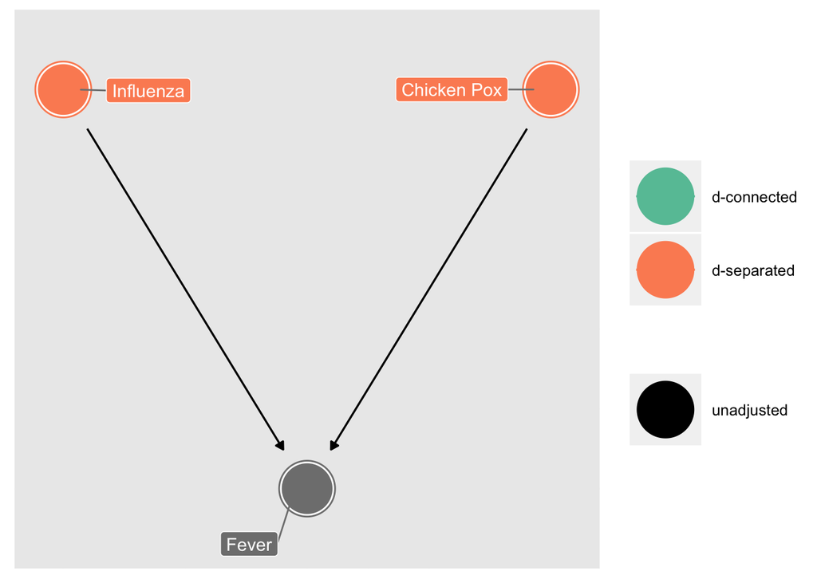

```r
ggdag_dseparated(fever_dag,
                 text = FALSE,
                 use_labels = "label")
```

What happens if we control for fever?

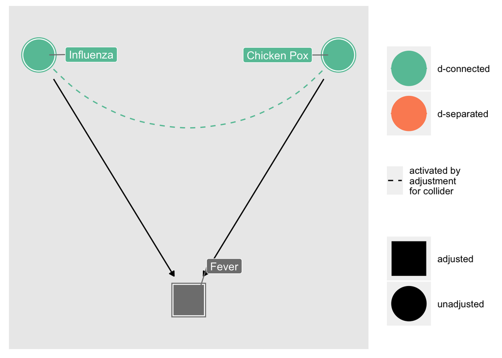

```r
ggdag_dseparated(fever_dag,
                 controlling_for = "m",
                 text = FALSE,
                 use_labels = "label")
```

We’ve induced an association between flu and chickenpox that wasn’t there before.

And what happens if we control for descendants of a collider?

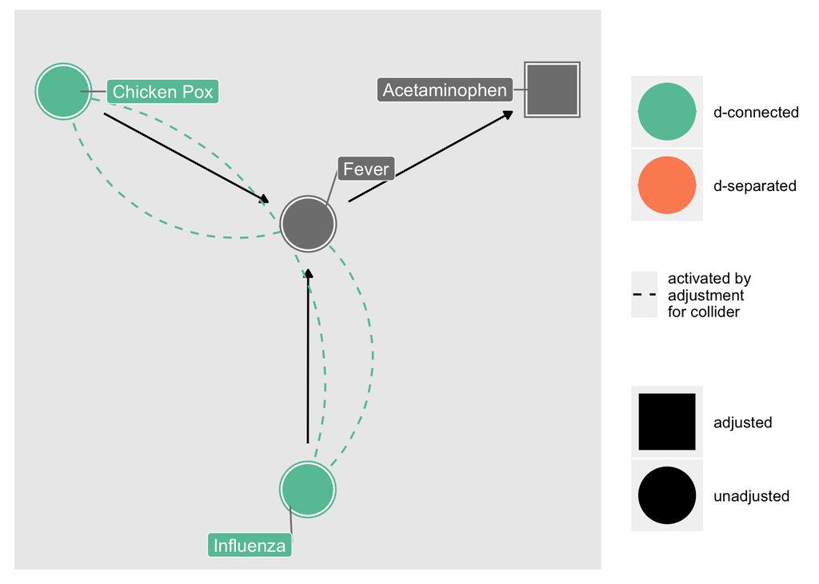

```r
dagify(fever ~ flu + pox,
       acetaminophen ~ fever,
       labels = c("flu" = "Influenza",
                  "pox" = "Chicken Pox",
                  "fever" = "Fever",
                  "acetaminophen" = "Acetaminophen")) %>%
  ggdag_dseparated(from = "flu",
                   to = "pox",
                   controlling_for = "acetaminophen",
                   text = FALSE,
                   use_labels = "label")
```

Same result - there’s now an association that wasn’t there before.